# Analýza hlavných komponentov (PCA)

- Zobraziť celý kód
- Skryť celý kód
- Zobraziť zdrojový kód

Softvér na analýzu údajov — Projektová správa

Autor

Artem Vara

Publikované

29. apríla 2026

# 1 Úvod

Moderná analýza dát sa čoraz častejšie stretáva s problémom **vysokej dimenzionality** — datasety môžu obsahovať desiatky až stovky premenných. Priama vizualizácia a interpretácia takýchto dát je prakticky nemožná. Jednou z najelegantnejších matematických metód na riešenie tohto problému je **Analýza hlavných komponentov** (PCA, z angl. *Principal Component Analysis*).

PCA je technika zo štatistiky a lineárnej algebry, ktorá transformuje pôvodné premenné na nové — navzájom nekorelované — premenné nazývané **hlavné komponenty**. Tieto komponenty sú usporiadané tak, aby prvý komponent vysvetľoval čo najväčší podiel celkovej variability dát, druhý komponent vysvetľoval čo najväčší podiel zo zvyšnej variability, atď.

Metóda nachádza uplatnenie v mnohých oblastiach:

- **Biológia**: klasifikácia druhov podľa morfologických znakov (Jolliffe a Cadima 2016)
- **Ekonomika**: redukcia makroekonomických indikátorov
- **Počítačové videnie**: rozpoznávanie tvárí (Eigenfaces)
- **Chémia**: spektroskopická analýza

Správa je členená nasledovne: v Sekcia 2 zhrnieme matematické pozadie metódy, Sekcia 3 popisuje použitý dataset, v Sekcia 4 vykonáme samotný výpočet PCA a v Sekcia 5 prezentujeme výsledky s vizualizáciami. Závery sú zhrnuté v Sekcia 6.

# 2 Teoretické pozadie

## 2.1 Kovariančná matica

Nech $\mathbf{X}$ je dátová matica rozmeru $n \times p$, kde $n$ je počet pozorovaní a $p$ je počet premenných. Po **štandardizácii** (odčítaním priemeru a delením smerodajnou odchýlkou) dostaneme maticu $\mathbf{Z}$.

Kovariančná (resp. korelačná) matica je definovaná ako:

$$\mathbf{C} = \frac{1}{n-1} \mathbf{Z}^\top \mathbf{Z}
\tag{1}$$

Matica $\mathbf{C}$ je symetrická a pozitívne semidefinitná rozmeru $p \times p$.

## 2.2 Vlastné čísla a vlastné vektory

Jadrom PCA je **spektrálny rozklad** kovariančnej matice definovanej v Rovnica 1:

$$\mathbf{C} \mathbf{v}_i = \lambda_i \mathbf{v}_i, \quad i = 1, \ldots, p
\tag{2}$$

kde $\lambda_i$ sú **vlastné čísla** (eigenvalues) a $\mathbf{v}_i$ sú zodpovedajúce **vlastné vektory** (eigenvectors). Vlastné vektory sú navzájom ortogonálne:

$$\mathbf{v}_i^\top \mathbf{v}_j = \begin{cases} 1 & i = j \\ 0 & i \neq j \end{cases}$$

## 2.3 Hlavné komponenty

**Hlavné komponenty** sú lineárne kombinácie pôvodných premenných:

$$\mathbf{PC}_k = \mathbf{Z} \mathbf{v}_k$$

Podiel variability vysvetlenej $k$-tym komponentom:

$$\text{PVE}_k = \frac{\lambda_k}{\sum_{i=1}^{p} \lambda_i}
\tag{3}$$

Vlastné vektory $\mathbf{v}_k$ sa nazývajú **loadings** (záťaže) a udávajú, ako silno každá pôvodná premenná prispieva k danému komponentu.

## 2.4 Algoritmus PCA — krok za krokom

1. Štandardizácia dát: $z_{ij} = \frac{x_{ij} - \bar{x}_j}{s_j}$
2. Výpočet kovariančnej matice (Rovnica 1): $\mathbf{C} = \frac{1}{n-1}\mathbf{Z}^\top\mathbf{Z}$
3. Spektrálny rozklad (Rovnica 2): $\mathbf{C} = \mathbf{V} \boldsymbol{\Lambda} \mathbf{V}^\top$
4. Zoradenie vlastných čísel: $\lambda_1 \geq \lambda_2 \geq \ldots \geq \lambda_p$
5. Projekcia dát: $\mathbf{PC} = \mathbf{Z} \mathbf{V}$

# 3 Dáta

## 3.1 Popis datasetu

Použijeme vstavaný R dataset `mtcars` (R Core Team 2024), ktorý obsahuje informácie o 32 modeloch automobilov z roku 1974. Prvých šesť riadkov datasetu zobrazuje Tabuľka 1.

**Kód**

```r
head(mtcars) |>
  kable(digits = 2) |>
  kable_styling(bootstrap_options = c("striped", "hover"), font_size = 12)
```

Tabuľka 1: Prvých 6 riadkov datasetu mtcars

|  | mpg | cyl | disp | hp | drat | wt | qsec | vs | am | gear | carb |
| --- | --- | --- | --- | --- | --- | --- | --- | --- | --- | --- | --- |
| Mazda RX4 | 21.0 | 6 | 160 | 110 | 3.90 | 2.62 | 16.46 | 0 | 1 | 4 | 4 |
| Mazda RX4 Wag | 21.0 | 6 | 160 | 110 | 3.90 | 2.88 | 17.02 | 0 | 1 | 4 | 4 |
| Datsun 710 | 22.8 | 4 | 108 | 93 | 3.85 | 2.32 | 18.61 | 1 | 1 | 4 | 1 |
| Hornet 4 Drive | 21.4 | 6 | 258 | 110 | 3.08 | 3.21 | 19.44 | 1 | 0 | 3 | 1 |
| Hornet Sportabout | 18.7 | 8 | 360 | 175 | 3.15 | 3.44 | 17.02 | 0 | 0 | 3 | 2 |
| Valiant | 18.1 | 6 | 225 | 105 | 2.76 | 3.46 | 20.22 | 1 | 0 | 3 | 1 |

Dataset obsahuje 32 pozorovaní a 11 premenných:

| Premenná | Popis |
| --- | --- |
| `mpg` | Spotreba paliva (míle na galón) |
| `cyl` | Počet valcov |
| `disp` | Objem motora (cu.in.) |
| `hp` | Výkon (konské sily) |
| `drat` | Prevodový pomer zadnej nápravy |
| `wt` | Hmotnosť (1000 lbs) |
| `qsec` | Čas na 1/4 míle |
| `vs` | Typ motora (V alebo priamy) |
| `am` | Prevodovka (0 = automatická, 1 = manuálna) |
| `gear` | Počet prevodových stupňov |
| `carb` | Počet karburátorov |

## 3.2 Korelácie medzi premennými

Pred PCA je užitočné preskúmať korelácie — výsledná korelačná matica je znázornená na Obrázok 1.

**Kód**

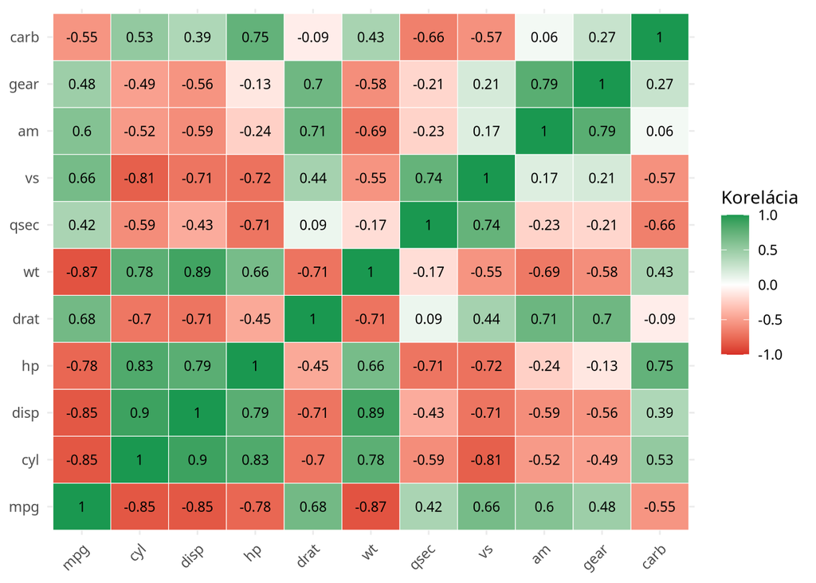

Obrázok 1: Korelačná matica premenných datasetu mtcars

```r
# Výpočet korelačnej matice
cor_mat <- cor(mtcars)

# Vizualizácia
cor_df <- as.data.frame(as.table(cor_mat))
names(cor_df) <- c("Var1", "Var2", "Correlation")

ggplot(cor_df, aes(Var1, Var2, fill = Correlation)) +
  geom_tile(color = "white") +
  geom_text(aes(label = round(Correlation, 2)), size = 3) +
  scale_fill_gradient2(low = "#d73027", mid = "white", high = "#1a9850",
                       midpoint = 0, limits = c(-1, 1)) +
  theme_minimal() +
  theme(axis.text.x = element_text(angle = 45, hjust = 1)) +
  labs(x = NULL, y = NULL, fill = "Korelácia")
```

Z korelačnej matice na Obrázok 1 vidíme silné korelácie medzi premennými (napr. `disp`, `cyl`, `hp`, `wt`), čo naznačuje, že PCA dokáže tieto premenné efektívne zlúčiť.

# 4 Výpočet PCA

## 4.1 Ručný výpočet cez kovariančnú maticu

Najskôr ukážeme PCA “od základov” — priamo cez spektrálny rozklad podľa postupu zo Sekcia 2.4:

**Kód**

```r
# Štandardizácia
Z <- scale(mtcars)

# Kovariančná matica
C <- cov(Z)

# Spektrálny rozklad
eig <- eigen(C)

# Vlastné čísla
lambda <- eig$values
cat("Vlastné čísla (prvých 5):\n")
```

```
Vlastné čísla (prvých 5):
```

**Kód**

```r
round(lambda[1:5], 4)
```

```
[1] 6.6084 2.6505 0.6272 0.2696 0.2235
```

**Kód**

```r
# Vlastné vektory (loadings)
V <- eig$vectors
cat("\nPrvé dva vlastné vektory (PC1 a PC2):\n")
```

```
Prvé dva vlastné vektory (PC1 a PC2):
```

**Kód**

```r
round(V[, 1:2], 3)
```

```
        [,1]   [,2]
 [1,]  0.363 -0.016
 [2,] -0.374 -0.044
 [3,] -0.368  0.049
 [4,] -0.330 -0.249
 [5,]  0.294 -0.275
 [6,] -0.346  0.143
 [7,]  0.200  0.463
 [8,]  0.307  0.232
 [9,]  0.235 -0.429
[10,]  0.207 -0.462
[11,] -0.214 -0.414
```

## 4.2 PCA pomocou funkcie prcomp()

**Kód**

```r
# PCA pomocou vstavanej funkcie
pca <- prcomp(mtcars, center = TRUE, scale. = TRUE)

# Súhrn
summary(pca)
```

```
Importance of components:
                          PC1    PC2     PC3     PC4     PC5     PC6    PC7
Standard deviation     2.5707 1.6280 0.79196 0.51923 0.47271 0.46000 0.3678
Proportion of Variance 0.6008 0.2409 0.05702 0.02451 0.02031 0.01924 0.0123
Cumulative Proportion  0.6008 0.8417 0.89873 0.92324 0.94356 0.96279 0.9751
                           PC8    PC9    PC10   PC11
Standard deviation     0.35057 0.2776 0.22811 0.1485
Proportion of Variance 0.01117 0.0070 0.00473 0.0020
Cumulative Proportion  0.98626 0.9933 0.99800 1.0000
```

## 4.3 Záťaže (Loadings)

Záťaže prvých štyroch hlavných komponentov sú uvedené v Tabuľka 2.

**Kód**

```r
loadings_df <- as.data.frame(pca$rotation[, 1:4])

loadings_df |>
  kable(digits = 3) |>
  kable_styling(bootstrap_options = c("striped", "hover")) |>
  column_spec(2, bold = TRUE, color = ifelse(abs(loadings_df$PC1) > 0.3, "#8B0000", "#000000"))
```

Tabuľka 2: Záťaže prvých štyroch hlavných komponentov

|  | PC1 | PC2 | PC3 | PC4 |
| --- | --- | --- | --- | --- |
| mpg | -0.363 | 0.016 | -0.226 | -0.023 |
| cyl | 0.374 | 0.044 | -0.175 | -0.003 |
| disp | 0.368 | -0.049 | -0.061 | 0.257 |
| hp | 0.330 | 0.249 | 0.140 | -0.068 |
| drat | -0.294 | 0.275 | 0.161 | 0.855 |
| wt | 0.346 | -0.143 | 0.342 | 0.246 |
| qsec | -0.200 | -0.463 | 0.403 | 0.068 |
| vs | -0.307 | -0.232 | 0.429 | -0.215 |
| am | -0.235 | 0.429 | -0.206 | -0.030 |
| gear | -0.207 | 0.462 | 0.290 | -0.265 |
| carb | 0.214 | 0.414 | 0.529 | -0.127 |

# 5 Výsledky a vizualizácia

## 5.1 Scree plot — vysvetlená variabilita

Podiel variability vysvetlenej jednotlivými komponentmi (PVE, Rovnica 3) znázorňuje scree plot na Obrázok 2.

**Kód**

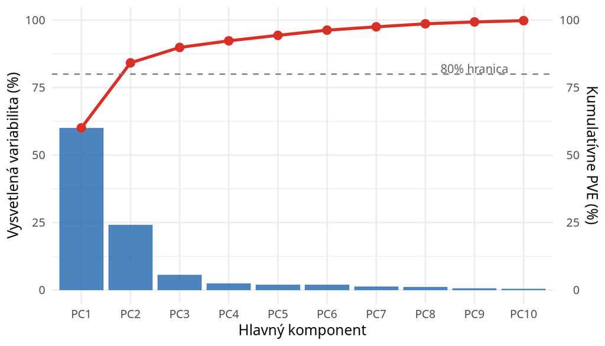

Obrázok 2: Scree plot: podiel vysvetlenej variability jednotlivými komponentmi

```r
# Výpočet PVE
pve <- lambda / sum(lambda) * 100
cumulative_pve <- cumsum(pve)

scree_df <- data.frame(
  PC = paste0("PC", 1:length(pve)),
  PVE = pve,
  Cumulative = cumulative_pve
)

ggplot(scree_df[1:10, ], aes(x = reorder(PC, -PVE))) +
  geom_col(aes(y = PVE), fill = "#2166ac", alpha = 0.8) +
  geom_line(aes(y = Cumulative, group = 1), color = "#d73027", size = 1.2) +
  geom_point(aes(y = Cumulative), color = "#d73027", size = 3) +
  geom_hline(yintercept = 80, linetype = "dashed", color = "gray50") +
  annotate("text", x = 9, y = 82, label = "80% hranica", color = "gray40", size = 3.5) +
  scale_y_continuous(sec.axis = sec_axis(~., name = "Kumulatívne PVE (%)")) +
  labs(x = "Hlavný komponent", y = "Vysvetlená variabilita (%)") +
  theme_minimal(base_size = 12)
```

Ako vidno na Obrázok 2, prvé dva komponenty vysvetľujú **84.2%** celkovej variability, prvé tri komponenty **89.9%**.

## 5.2 Biplót — projekcia do 2D priestoru

Projekciu pozorovaní do roviny prvých dvoch komponentov spolu s vektormi záťaží zobrazuje Obrázok 3.

**Kód**

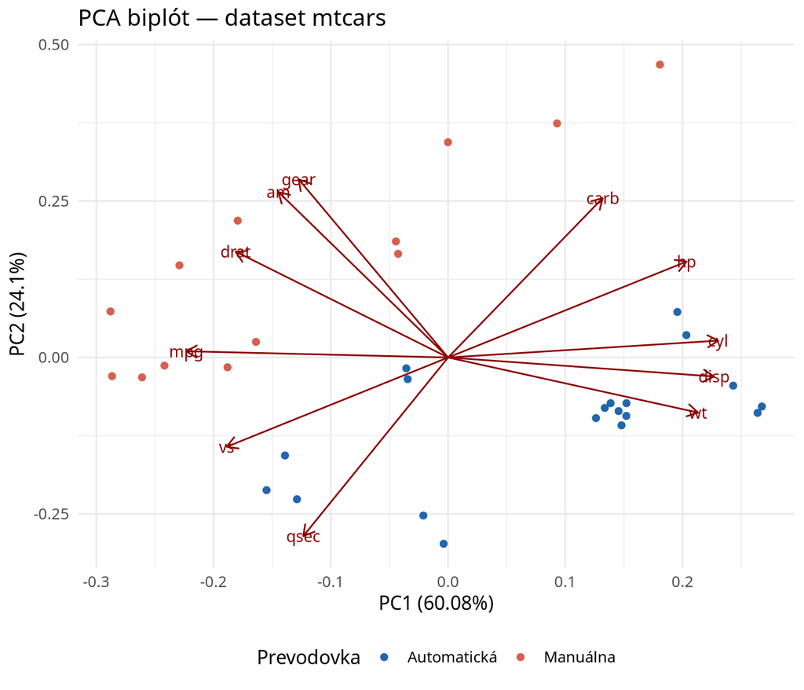

Obrázok 3: Biplót PCA: projekcia automobilov do roviny PC1–PC2 s vektormi záťaží

```r
# Pridáme typ prevodovky ako faktor
mtcars_labeled <- mtcars |>
  mutate(
    transmission = factor(am, labels = c("Automatická", "Manuálna")),
    car_name = rownames(mtcars)
  )

autoplot(pca, data = mtcars_labeled,
         colour = "transmission",
         loadings = TRUE,
         loadings.label = TRUE,
         loadings.label.size = 3.5,
         loadings.colour = "darkred",
         loadings.label.colour = "darkred") +
  scale_color_manual(values = c("#2166ac", "#d6604d")) +
  labs(color = "Prevodovka", title = "PCA biplót — dataset mtcars") +
  theme_minimal(base_size = 12) +
  theme(legend.position = "bottom")
```

## 5.3 Interpretácia komponentov

Záťaže premenných na prvých dvoch komponentoch (porovnaj s Tabuľka 2) sú vizualizované na Obrázok 4.

**Kód**

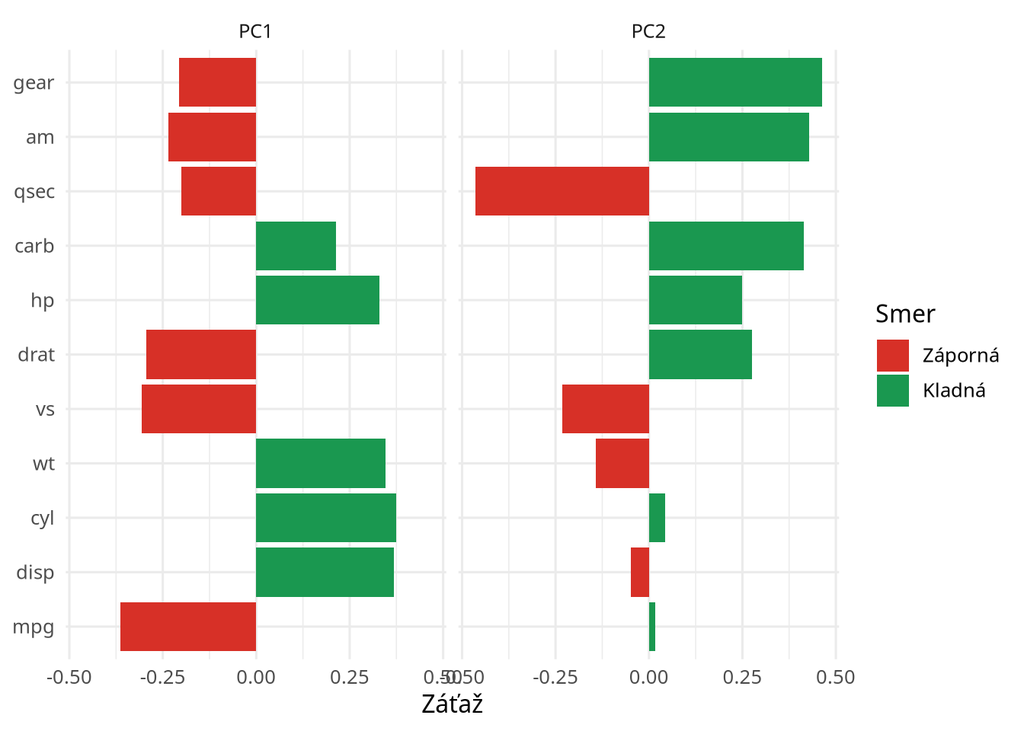

Obrázok 4: Záťaže premenných na prvých dvoch komponentoch

```r
loadings_long <- as.data.frame(pca$rotation[, 1:2]) |>
  mutate(variable = rownames(pca$rotation)) |>
  pivot_longer(cols = c(PC1, PC2), names_to = "PC", values_to = "loading")

ggplot(loadings_long, aes(x = reorder(variable, abs(loading)), y = loading, fill = loading > 0)) +
  geom_col() +
  facet_wrap(~PC) +
  coord_flip() +
  scale_fill_manual(values = c("#d73027", "#1a9850"), labels = c("Záporná", "Kladná")) +
  labs(x = NULL, y = "Záťaž", fill = "Smer") +
  theme_minimal(base_size = 12)
```

**PC1** (vysvetľuje 60.1% variability) je silne spojený s výkonom a veľkosťou motora (`hp`, `disp`, `cyl`, `wt`) — môžeme ho interpretovať ako **“silu vozidla”**. Premenné `mpg` a `drat` majú záporné záťaže (Obrázok 4), čo znamená, že silnejšie autá majú vyššiu spotrebu.

# 6 Záver

PCA zostáva jednou z najpoužívanejších metód exploratívnej analýzy dát vďaka svojej matematickej jednoduchosti a širokej aplikovateľnosti (R Core Team 2024).

# Literatúra

Jolliffe, Ian T., a Jorge Cadima. 2016. *Principal Component Analysis*. 2nd vyd. New York: Springer. https://doi.org/10.1007/b98835.

R Core Team. 2024. *R: A Language and Environment for Statistical Computing*. Vienna, Austria: R Foundation for Statistical Computing. https://www.R-project.org/.